# Project 5 - FMT

#### After Sampling of the Dataset

## Under-Sampling

```python
failed_tests = np.array(data[data['Pass/Fail'] == 1].index)
no_failed_tests = len(failed_tests)

print(no_failed_tests)
```

```
104
```

```python
normal_indices = data[data['Pass/Fail'] == -1]
no_normal_indices = len(normal_indices)

print(no_normal_indices)
```

```
1463
```

```python
random_normal_indices = np.random.choice(no_normal_indices, size = no_failed_tests, replace = True)
random_normal_indices = np.array(random_normal_indices)

print(len(random_normal_indices))
```

```
104
```

```python
under_sample = np.concatenate([failed_tests, random_normal_indices])
print(len(under_sample))
```

```
208
```

```python
undersample_data = data.iloc[under_sample, :]
```

```python
x = undersample_data.iloc[:, undersample_data.columns != 'Pass/Fail']
y = undersample_data.iloc[:, undersample_data.columns == 'Pass/Fail']

print(x.shape)
print(y.shape)
```

```
(208, 590)
(208, 1)
```

```python
# Test-Train split, 80:20 ratio

x_train, x_test, y_train, y_test = train_test_split(x, y, test_size = 0.2, random_state = 42)

print(x_train.shape)
print(y_train.shape)
print(x_test.shape)
print(y_test.shape)
```

```
(166, 590)
(166, 1)
(42, 590)
(42, 1)
```

```python
# Standard Scaling

sc = StandardScaler()
x_train = sc.fit_transform(x_train)
x_test = sc.transform(x_test)
```

#### fitting various models

##### Random Forest

```python
model = RandomForestClassifier()
model.fit(x_train, y_train)

y_pred = model.predict(x_test)

print("Training Accuracy: ", model.score(x_train, y_train))
print('Testing Accuarcy: ', model.score(x_test, y_test))
```

```
Training Accuracy:  1.0
Testing Accuarcy:  0.5476190476190477
```

[figure not shown]

```python
cm = confusion_matrix(y_test, y_pred)

plt.rcParams['figure.figsize'] = (7, 5)
plt.title('Confusion Matrix for Decision Tree Classifer')
sns.set(style = 'dark', font_scale = 1.4)
sns.heatmap(cm, annot = True, annot_kws = {"size": 15}, cmap= 'autumn', fmt= 'g');
```

```python
Anomaly_accuracy = np.float(13/22)
print("Anomaly Detection Accuracy: ", Anomaly_accuracy*100,"%")
```

```
Anomaly Detection Accuracy:  59.09090909090909 %
```

```python
prc = average_precision_score(y_test, y_pred)
print("Precision Recall Score: {0:0.2f}" .format(prc),"%")
```

```
Precision Recall Score: 0.56 %
```

##### Decision Tree

```python
model = DecisionTreeClassifier()
model.fit(x_train, y_train)

y_pred = model.predict(x_test)

print("Training Accuracy: ", model.score(x_train, y_train))
print('Testing Accuarcy: ', model.score(x_test, y_test))
```

```
Training Accuracy:  1.0
Testing Accuarcy:  0.5714285714285714
```

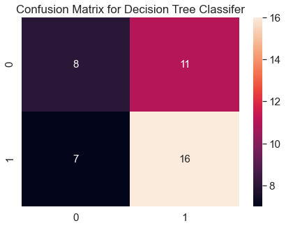

```python
cm = confusion_matrix(y_test, y_pred)

plt.rcParams['figure.figsize'] = (7, 5)
plt.title('Confusion Matrix for Decision Tree Classifer')
sns.set(style = 'dark', font_scale = 1.4)
sns.heatmap(cm, annot = True, annot_kws = {"size": 15}, cmap= 'rocket', fmt= 'g');
```

```python
Anomaly_accuracy = np.float(13/22)
print("Anomaly Detection Accuracy: ", Anomaly_accuracy*100, "%")
```

[output not shown]

```python
prc = average_precision_score(y_test, y_pred)
print("Precision Recall Score: {0:0.2f}" .format(prc), "%")
```

```
Precision Recall Score: 0.58 %
```

##### Xg- Boost Classifier

```python
model = XGBClassifier(max_depth = 1)
model.fit(x_train, y_train)
y_pred = model.predict(x_test)
print("Testing Accuracy: ", model.score(x_test, y_test))
```

```
[13:07:04] WARNING: /opt/concourse/worker/volumes/live/7a2b9f41-3287-451b-6691-43e9a6c0910f/volume/xgboost-split_1619728204606/work/src/learner.cc:1061: Starting in XGBoost 1.3.0, the default evaluation metric used with the objective 'binary:logistic' was changed from 'error' to 'logloss'. Explicitl…
Testing Accuracy:  0.5476190476190477
```

```python
probabilities = model.fit(x_train, y_train).predict_proba(x_test)
print('AUPRC = {}'.format(average_precision_score(y_test, probabilities[:, 1])))
```

```
[13:07:04] WARNING: /opt/concourse/worker/volumes/live/7a2b9f41-3287-451b-6691-43e9a6c0910f/volume/xgboost-split_1619728204606/work/src/learner.cc:1061: Starting in XGBoost 1.3.0, the default evaluation metric used with the objective 'binary:logistic' was changed from 'error' to 'logloss'. Explicitl…
AUPRC = 0.7270959868114688
```

[figure not shown]

```python
cm = confusion_matrix(y_test, y_pred)

plt.rcParams['figure.figsize'] = (7, 5)
plt.title('Confusion Matrix for Decision Tree Classifer')
sns.set(style = 'dark', font_scale = 1.4)
sns.heatmap(cm, annot = True, annot_kws = {"size": 15}, cmap= 'rocket', fmt= 'g');
```

```python
Anomaly_accuracy = np.float(17/22)
print("Anomaly Detection Accuracy: ", Anomaly_accuracy*100,"%")
```

```
Anomaly Detection Accuracy:  77.27272727272727 %
```

```python
weights = (y == 0).sum()/(1.0*(y == -1).sum())
trainSizes, trainScores, crossValScores = learning_curve(XGBClassifier(max_depth = 5, scale_pos_weights = weights, n_jobs = 4),
                                                         x_train, y_train, scoring = 'average_precision')
```

[output not shown]

[output cut: 170 more lines]

[output not shown]

[figure not shown]

```python
trainScoresMean = np.mean(trainScores, axis=1)
trainScoresStd = np.std(trainScores, axis=1)
crossValScoresMean = np.mean(crossValScores, axis=1)
crossValScoresStd = np.std(crossValScores, axis=1)

colours = plt.cm.tab10(np.linspace(0, 1, 9))

fig = plt.figure(figsize = (14, 9))
plt.fill_between(trainSizes, trainScoresMean - trainScoresStd, trainScoresMean + trainScoresStd, alpha=0.1, color=colours[0])
plt.fill_between(trainSizes, crossValScoresMean - crossValScoresStd, crossValScoresMean + crossValScoresStd, alpha=0.1, color=colours[1])


plt.plot(trainSizes, trainScores.mean(axis = 1), 'o-', label = 'train', color = colours[0])
plt.plot(trainSizes, crossValScores.mean(axis = 1), 'o-', label = 'cross-val', color = colours[1])

ax = plt.gca()
for axis in ['top','bottom','left','right']:
    ax.spines[axis].set_linewidth(2)

handles, labels = ax.get_legend_handles_labels()
plt.legend(handles, ['train', 'cross-val'], bbox_to_anchor=(0.8, 0.15), \
               loc=2, borderaxespad=0, fontsize = 16);
plt.xlabel('training set size', size = 16);
plt.ylabel('AUPRC', size = 16)
plt.title('Learning curves indicate slightly underfit model', size = 20);
```

[figure not shown]

```python
n_groups = 3
Test_Accuracy = (59.5, 64, 57 )
Anomaly_Detection_Accuracy = (59, 59, 77.2)
Precision_Recall_Accuracy = (57, 61, 60.2)


# create plot
fig, ax = plt.subplots()
index = np.arange(n_groups)
bar_width = 0.15

rects1 = plt.bar(index, Test_Accuracy, bar_width, alpha = 0.5, color = 'blue', label = 'Test Accuracy')
rects2 = plt.bar(index + bar_width, Anomaly_Detection_Accuracy, bar_width, alpha = 0.5, color = 'lightblue', label = 'Anamoly Detection Accuracy')
rects3 = plt.bar(index + 2*bar_width, Precision_Recall_Accuracy, bar_width, alpha = 0.5 , color = 'cyan', label = 'Precision Recall Accuracy' )

plt.rcParams['figure.figsize'] = (10, 10)
plt.xlabel('Accuracy')
plt.ylabel('Scores')
plt.title('Accuracy by different Classifiers')
plt.xticks(index + 2*bar_width, ('RandomForest', 'DecisionTree', 'XgBoost'))
plt.legend()
plt.tight_layout()
plt.show()
```

### SMOTE - (Over-Sampling) to treat the Anamoly Detection

```python
x_resample, y_resample  = SMOTE().fit_resample(x, y.values.ravel())

print(x_resample.shape)
print(y_resample.shape)
```

```
(240, 590)
(240,)
```

```python
# test-train split, 80:20

x_train, x_test, y_train, y_test = train_test_split(x, y, test_size = 0.2, random_state = 0)

print(x_train.shape)
print(y_train.shape)
print(x_test.shape)
print(y_test.shape)
```

```
(166, 590)
(166, 1)
(42, 590)
(42, 1)
```

```python
# standardization

sc = StandardScaler()
x_train = sc.fit_transform(x_train)
x_test = sc.transform(x_test)
```

#### Random forest classifier

```python
model = RandomForestClassifier()
model.fit(x_train, y_train)

y_pred = model.predict(x_test)

print("Training Accuracy: ", model.score(x_train, y_train))
print('Testing Accuarcy: ', model.score(x_test, y_test))
```

```
Training Accuracy:  1.0
Testing Accuarcy:  0.7619047619047619
```

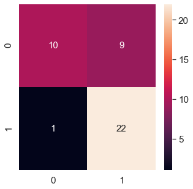

```python
cm = confusion_matrix(y_test, y_pred)

plt.rcParams['figure.figsize'] = (5, 5)
sns.set(style = 'dark', font_scale=1.4)
sns.heatmap(cm, annot = True, annot_kws = {"size": 15}, cmap= 'rocket', fmt= 'g');
```

```python
Anomaly_accuracy = np.float(18/22)
print("Anomaly Detection Accuracy: ", Anomaly_accuracy*100,"%")
```

[output not shown]

#### Gradient Boosting Classifier

```python
model  = GradientBoostingClassifier()

model.fit(x_train, y_train)

y_pred = model.predict(x_test)

print("Training Accuracy :", model.score(x_train, y_train))
print("Testing Accuracy :", model.score(x_test, y_test))
```

```
Training Accuracy : 1.0
Testing Accuracy : 0.6904761904761905
```

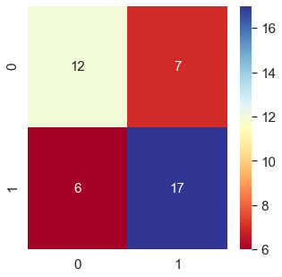

```python
cm = confusion_matrix(y_test, y_pred)

plt.rcParams['figure.figsize'] = (5, 5)
sns.set(style = 'dark', font_scale=1.4)
sns.heatmap(cm, annot = True, annot_kws = {"size": 15}, cmap= 'RdYlBu', fmt= 'g');
```

```python
Anamoly_accuracy = np.float(18/22)
print("Anamoly Detection Accuracy: ", Anamoly_accuracy*100,"%")
```

[output not shown]

#### Xg Boost Classifier

```python
model = XGBClassifier()
model.fit(x_train, y_train)
y_pred = model.predict(x_test)
```

[output not shown]

Selection of metric: Since the data is highly skewed, I use the area under the precision-recall curve (AUPRC) rather than the conventional area under the receiver operating characteristic (AUROC). This is because the AUPRC is more sensitive to differences between algorithms and their parameter settings rather than the AUROC

### Hyper Parameter Tuning for Xg-Boost

```python
parameters = [{'max_depth' : [1, 10, 5, 7]}]

grid_search = GridSearchCV(estimator = model, param_grid = parameters, scoring = 'accuracy', cv = 2, n_jobs = -1)

grid_search = grid_search.fit(x_train, y_train)
best_accuracy = grid_search.best_score_
best_parameters = grid_search.best_params_
```

[output not shown]

```python
print("Best Accuracy: ", best_accuracy)
print("Best Parameter: ", best_parameters)
```

```
Best Accuracy:  0.5662650602409639
Best Parameter:  {'max_depth': 10}
```

```python
weights = (y == 0).sum()/(1.0*(y == -1).sum())
model = XGBClassifier(max_depth = 1, scale_pos_weights = weights, n_jobs = 4)

model.fit(x_train, y_train)

y_pred = model.predict(x_test)

print("Training Accuracy :", model.score(x_train, y_train))
print("Testing Accuracy :", model.score(x_test, y_test))
```

[output not shown]

[figure not shown]

```python
colors = plt.cm.Set1(np.linspace(0, 1, 9))
xgb.plot_importance(model, height = 1, color = colors, grid = False, importance_type = 'cover', show_values = False)

plt.rcParams['figure.figsize'] = (10, 30)
plt.title('The Feature Importances in a Model', fontsize = 30)
plt.xlabel('The F-Score for each features')
plt.ylabel('Importances')
plt.show()
```

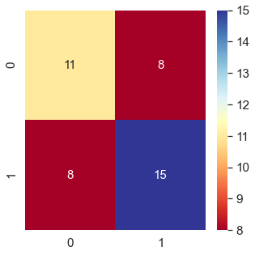

```python
cm = confusion_matrix(y_test, y_pred)

plt.rcParams['figure.figsize'] = (5, 5)
sns.set(style = 'dark', font_scale=1.4)
sns.heatmap(cm, annot = True, annot_kws = {"size": 15}, cmap= 'RdYlBu', fmt= 'g');
```

```python
Anomaly_accuracy = np.float(19/22)
print("Anomaly Detection Accuracy: ", Anomaly_accuracy*100, "%")
```

[output not shown]

[figure not shown]

```python
trainScoresMean = np.mean(trainScores, axis=1)
trainScoresStd = np.std(trainScores, axis=1)
crossValScoresMean = np.mean(crossValScores, axis=1)
crossValScoresStd = np.std(crossValScores, axis=1)

colours = plt.cm.tab10(np.linspace(0, 1, 9))

fig = plt.figure(figsize = (14, 9))
plt.fill_between(trainSizes, trainScoresMean - trainScoresStd, trainScoresMean + trainScoresStd, alpha=0.1, color=colours[0])
plt.fill_between(trainSizes, crossValScoresMean - crossValScoresStd, crossValScoresMean + crossValScoresStd, alpha=0.1, color=colours[1])


plt.plot(trainSizes, trainScores.mean(axis = 1), 'o-', label = 'train', color = colours[0])
plt.plot(trainSizes, crossValScores.mean(axis = 1), 'o-', label = 'cross-val', color = colours[1])

ax = plt.gca()
for axis in ['top','bottom','left','right']:
    ax.spines[axis].set_linewidth(2)

handles, labels = ax.get_legend_handles_labels()
plt.legend(handles, ['train', 'cross-val'], bbox_to_anchor=(0.8, 0.15), \
               loc=2, borderaxespad=0, fontsize = 16);
plt.xlabel('training set size', size = 16);
plt.ylabel('AUPRC', size = 16)
plt.title('Learning curves indicate slightly underfit model', size = 20);
```

```python
probabilities = model.fit(x_train, y_train).predict_proba(x_test)
print('AUPRC = {}'.format(average_precision_score(y_test, probabilities[:, 1])))
```

[output not shown]

### Hyper-Parameter Tuning for Naive Bayes Classifier

```python
model  = GaussianNB()

model.fit(x_train, y_train)

y_pred = model.predict(x_test)

print("Training Accuracy :", model.score(x_train, y_train))
print("Testing Accuracy :", model.score(x_test, y_test))
```

```
Training Accuracy : 0.6686746987951807
Testing Accuracy : 0.6190476190476191
```

```python
parameters = [{'priors': [None], 'var_smoothing': [1.0, 2.0, 3.0, 4.0, 5.0, 6.0]}]

grid_search = GridSearchCV(estimator = model, param_grid = parameters, scoring = 'accuracy', cv = 2, n_jobs = -1)

grid_search = grid_search.fit(x_train, y_train)
best_accuracy = grid_search.best_score_
best_parameters = grid_search.best_params_
```

```python
print("Best Accuracy: ", best_accuracy)
print("Best Parameter: ", best_parameters)
```

```
Best Accuracy:  0.4518072289156626
Best Parameter:  {'priors': None, 'var_smoothing': 1.0}
```

```python
model  = GaussianNB(priors = None, var_smoothing = 1.0)
model.fit(x_train, y_train)
y_pred = model.predict(x_test)

print("Training Accuracy :", model.score(x_train, y_train))
print("Testing Accuracy :", model.score(x_test, y_test))
```

```
Training Accuracy : 0.5301204819277109
Testing Accuracy : 0.5476190476190477
```

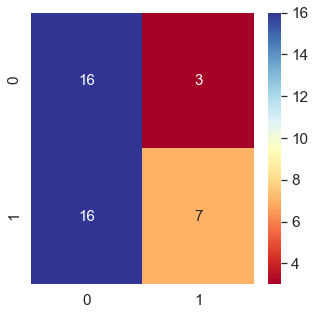

```python
cm = confusion_matrix(y_test, y_pred)

plt.rcParams['figure.figsize'] = (5, 5)
sns.set(style = 'dark', font_scale=1.4)
sns.heatmap(cm, annot = True, annot_kws = {"size": 15}, cmap= 'RdYlBu', fmt= 'g');
```

```python
Anomaly_accuracy = np.float(10/22)
print("Anomaly Detection Accuracy: ", Anomaly_accuracy*100,"%")
```

[output not shown]

### Hyper Parameter Tuning for Support Vector Classifier

```python
svm = SVC()

svm.fit(x_train, y_train)

y_pred = svm.predict(x_test)

print("Training Accuracy :", svm.score(x_train, y_train))
print("Testing Accuracy :", svm.score(x_test, y_test))
```

```
Training Accuracy : 0.9939759036144579
Testing Accuracy : 0.7380952380952381
```

```python
parameters = [{'C': [1, 0.1, 0.0001, 0.000001], 'kernel': ['linear', 'rbf'], 'gamma': [0.0000001, 0.0001, 0.001, 0.01]}]

grid_search = GridSearchCV(estimator = svm,
                           param_grid = parameters,
                           scoring = 'accuracy',
                           cv = 2,
                           n_jobs = -1)


grid_search = grid_search.fit(x_train, y_train)
best_accuracy = grid_search.best_score_
best_parameters = grid_search.best_params_
```

```python
print("Best Accuracy: ", best_accuracy)
print("Best Parameters :", best_parameters)
```

```
Best Accuracy:  0.5963855421686748
Best Parameters : {'C': 1, 'gamma': 0.01, 'kernel': 'rbf'}
```

```python
svm_model  = SVC( C = 1, gamma = 0.001, kernel = 'rbf')

svm_model.fit(x_train, y_train)

y_pred = svm_model.predict(x_test)

print("Training Accuracy :", svm_model.score(x_train, y_train))
print("Testing Accuracy :", svm_model.score(x_test, y_test))
```

```
Training Accuracy : 0.8614457831325302
Testing Accuracy : 0.5952380952380952
```

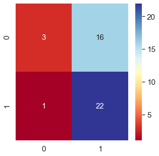

```python
cm = confusion_matrix(y_test, y_pred)

plt.rcParams['figure.figsize'] = (5, 5)
sns.set(style = 'dark', font_scale=1.4)
sns.heatmap(cm, annot = True, annot_kws = {"size": 15}, cmap= 'RdYlBu', fmt= 'g');
```

```python
Anomaly_accuracy = np.float(20/22)
print("Anomaly Detection Accuracy: ", Anomaly_accuracy*100, "%")
```

[output not shown]

```python
prc = average_precision_score(y_test, y_pred)
print("Precision Recall Score: {0:0.2f}" .format(prc),"%")
```

```
Precision Recall Score: 0.58 %
```

```python
pca = PCA(n_components = None)
pca.fit(x_train)
print(pca.explained_variance_ratio_)
```

```
[7.19871545e-02 5.90315728e-02 4.22645107e-02 3.13818974e-02
 2.87826318e-02 2.50018809e-02 2.25934224e-02 2.21636145e-02
 2.15958792e-02 2.07431809e-02 1.99110045e-02 1.93462998e-02
 1.87355912e-02 1.77297416e-02 1.72865644e-02 1.68992382e-02
 1.59439574e-02 1.55236103e-02 1.47335032e-02 1.41646429e-02
 1.39413328e-02 1.38090441e-02 1.29982541e-02 1.27183942e-02
 1.25520980e-02 1.20350710e-02 1.15247147e-02 1.11399585e-02
 1.08473949e-02 1.06333094e-02 1.01826262e-02 9.95656902e-03
 9.81751905e-03 9.54476586e-03 9.41193799e-03 8.89520837e-03
 8.81483067e-03 8.35293288e-03 8.14936674e-03 7.90915632e-03
 7.80102231e-03 7.73540700e-03 7.62735034e-03 7.24644833e-03
 7.07116519e-03 6.82532973e-03 6.80743511e-03 6.42534269e-03
 6.36008620e-03 6.04979961e-03 5.83526201e-03 5.71335050e-03
 5.49817882e-03 5.41751302e-03 5.27447868e-03 5.23041472e-03
 5.07698097e-03 5.04067819e-03 4.81538329e-03 4.76459533e-03
 4.57412529e-03 4.49499625e-03 4.39845387e-03 4.28916324e-03
 4.24156602e-03 4.05268757e-03 4.01906157e-03 3.91411450e-03
 3.76243328e-03 3.57539598e-03 3.57097823e-03 3.49876553e-03
 3.35017148e-03 3.17004764e-03 3.12172382e-03 3.10337890e-03
 2.93084176e-03 2.92794244e-03 2.83233755e-03 2.80227323e-03
 2.68111247e-03 2.58446170e-03 2.42904671e-03 2.38472723e-03
 2.28151551e-03 2.26748276e-03 2.23704195e-03 2.15241271e-03
 2.09014438e-03 2.02489369e-03 2.00164586e-03 1.94916864e-03
 1.92537325e-03 1.83626030e-03 1.79053273e-03 1.75302323e-03
 1.73086589e-03 1.66501669e-03 1.62822209e-03 1.56573517e-03
 1.51939205e-03 1.47462815e-03 1.40088970e-03 1.35115680e-03
 1.33198280e-03 1.30125182e-03 1.23369220e-03 1.19555471e-03
 1.16296346e-03 1.08441869e-03 1.03534157e-03 1.03037787e-03
 9.89976672e-04 9.68897874e-04 9.18291255e-04 8.70000792e-04
 8.54668095e-04 8.26283573e-04 7.86219559e-04 7.48304188e-04
 7.37775185e-04 7.28828052e-04 7.06787768e-04 6.61568471e-04
 6.13591740e-04 5.99067255e-04 5.79070285e-04 5.43039437e-04
 5.16155873e-04 5.12201247e-04 5.01084471e-04 4.83818229e-04
 4.63226143e-04 4.26354262e-04 4.04393934e-04 3.93250174e-04
 3.62204320e-04 3.52107346e-04 3.26406864e-04 3.08388078e-04
 3.02617976e-04 2.82963165e-04 2.57765524e-04 2.50656161e-04
 2.19144051e-04 2.14343534e-04 1.99209240e-04 1.92163296e-04
 1.73920671e-04 1.66189137e-04 1.57669652e-04 1.41969630e-32
 1.48982260e-33 8.76916952e-34 5.73717419e-34 2.84199456e-34
 2.84199456e-34 2.84199456e-34 2.84199456e-34 2.84199456e-34
 2.84199456e-34 2.84199456e-34 2.84199456e-34 2.84199456e-34
 1.30130110e-34 6.30709460e-35]
```

After Applying PCA we can clearly see that we can perform Principal Component Analysis (Dimensionality Reduction because all the 590 attributes are not contributing in a big way to the result hence we can undermine the attributes which are less responsible to reach to the result, it will be helpgul for reducing the complexity as the number of columns is very high.)

```python
pca = PCA(n_components = 30)
pca.fit(x_train)
```

```
PCA(n_components=30)
```

```python
model  = SVC()

model.fit(x_train, y_train)

y_pred = model.predict(x_test)

print("Training Accuracy :", model.score(x_train, y_train))
print("Testing Accuracy :", model.score(x_test, y_test))
```

```
Training Accuracy : 0.9939759036144579
Testing Accuracy : 0.7380952380952381
```

```python
prc = average_precision_score(y_test, y_pred)
print("Precision Recall Score: {0:0.2f}" .format(prc),"%")
```

```
Precision Recall Score: 0.69 %
```

## Observation time!

First up, the data set is humongous and not at all easy to understand and for a good duration would need a domain expert to help me understand the colums and their usages. what I have done here, is purely based on the analytics shown by the data. since this is a semi conductor manufacturing process data, where things are collected runtime to deduce the quality to be good or not.

univariate and bivariate analysis are difficult to guage as the understanding of data set itself is a question mark. the heat map shows some correlation but the same is not easily deducible. though some columns do show some strong correlations

The dataset has the following characteristics:

```
- two-class problem
- an imbalance with a 14:1 skew of pass to fails
- large number of features -- 590
- missing data
- features/columns which do not have sufficient information
- 4% of the columns/features have more than 50% of their records missing
- some columns have constant values
```

After an exhaustive model building exercise emcompassing undersampling, over sampling, CV and hyper parameter tuning. we will look at the anomaly detection % to select the best model that i would want to pickle up and use on the future data to see how it performs on any unseen data

Scrolling through the model lists , `Hyper Parameter Tuning for Support Vector Classifier` stands out with the best anomaly detection model with over `90% chance of detecting an anomaly` and after consulting with a domain expert on the % success value, we can deploy the same to prod.

I will be pickling the same for further use.

## Pickle model

```python
saved_model = pickle.dumps(svm_model)
```

```python
svm_from_pickle = pickle.loads(saved_model)
```

```python
svm_from_pickle.predict(x_test)
```

```
array([ 1,  1,  1,  1,  1,  1,  1,  1,  1,  1,  1, -1,  1,  1,  1,  1,  1,
        1,  1,  1,  1,  1,  1,  1,  1,  1,  1,  1,  1,  1, -1, -1,  1,  1,
        1,  1,  1, -1,  1,  1,  1,  1])
```

### Import the unseen data/Future data file and check model performance.

```python
# read future data

future = pd.read_csv('Future_predictions.csv')
```

```python
future.shape
```

```
(18, 591)
```

```python
future.head(5)
```

|  | Time | 0 | 1 | 2 | 3 | 4 | 5 | 6 | 7 | 8 | ... | 580 | 581 | 582 | 583 | 584 | 585 | 586 | 587 | 588 | 589 |
| --- | --- | --- | --- | --- | --- | --- | --- | --- | --- | --- | --- | --- | --- | --- | --- | --- | --- | --- | --- | --- | --- |
| 0 | 19/07/08 11:55 | 3030.93 | 2564.00 | 2187.7333 | 1411.1265 | 1.3602 | 100 | 97.6133 | 0.1242 | 1.5005 | ... | NaN | NaN | 0.5005 | 0.0118 | 0.0035 | 2.3630 | NaN | NaN | NaN | NaN |
| 1 | 19/07/08 12:32 | 3095.78 | 2465.14 | 2230.4222 | 1463.6606 | 0.8294 | 100 | 102.3433 | 0.1247 | 1.4966 | ... | 0.0060 | 208.2045 | 0.5019 | 0.0223 | 0.0055 | 4.4447 | 0.0096 | 0.0201 | 0.0060 | 208.2045 |
| 2 | 19/07/08 13:17 | 2932.61 | 2559.94 | 2186.4111 | 1698.0172 | 1.5102 | 100 | 95.4878 | 0.1241 | 1.4436 | ... | 0.0148 | 82.8602 | 0.4958 | 0.0157 | 0.0039 | 3.1745 | 0.0584 | 0.0484 | 0.0148 | 82.8602 |
| 3 | 19/07/08 14:43 | 2988.72 | 2479.90 | 2199.0333 | 909.7926 | 1.3204 | 100 | 104.2367 | 0.1217 | 1.4882 | ... | 0.0044 | 73.8432 | 0.4990 | 0.0103 | 0.0025 | 2.0544 | 0.0202 | 0.0149 | 0.0044 | 73.8432 |
| 4 | 19/07/08 15:22 | 3032.24 | 2502.87 | 2233.3667 | 1326.5200 | 1.5334 | 100 | 100.3967 | 0.1235 | 1.5031 | ... | NaN | NaN | 0.4800 | 0.4766 | 0.1045 | 99.3032 | 0.0202 | 0.0149 | 0.0044 | 73.8432 |

5 rows × 591 columns

```python
# Dropping the time column as done in the original dataset.

future = future.drop(['Time'],axis=1)
```

```python
# fill null with 0

future.fillna(0, inplace=True)
```

```python
future.isnull().sum()
```

```
0      0
1      0
2      0
3      0
4      0
      ..
585    0
586    0
587    0
588    0
589    0
Length: 590, dtype: int64
```

```python
svm_from_pickle.predict(future)
```

```
array([1, 1, 1, 1, 1, 1, 1, 1, 1, 1, 1, 1, 1, 1, 1, 1, 1, 1])
```

## Conclusions

- This was a totally unfamiliar dataset with no column names trying to help with what the data could be, however during model building a lot of important feature were classified by DT, XG, which when we sit with a domain expert and understand the use of the same, will help us make a better model
- For now, i have concentrated solely in finding the `anomaly detection %` of the model using different methods and finally come up with the model hyper tuned using GridSearchCV method and that model is able to predict `90+% anomalies` which is great start and can be improved on if we get better answers for the below questions.
- a lot of column had null or 0 value, which was imputed with 0 for model building, but this needs to be cross checked with a domain expert to understand if those columns had any value in model making OR was the approach right, otherwise the model will perform horribly bad on prod datasets and that is a point of failure.
- the target classes were highly imbalanced as captured, is this expected always
- PCA or dimensionality reduction is doing no good as first up the data set is unclear in the terms of attributes and the PCA's dataframe would be even bad while trying to explain the model
- The SVM combined with a sampling strategy holds promise and we will next look at a combination of oversampling (the minority class) and undersampling (the majority class).